# Presentación de datos - Por Castelli Nahuel

## Premier League Match Data 2021-2022

Los datos de esta semana provienen de los datos de los partidos de la Premier League 2021-2022 a través de Evan Gower en Kaggle. Ver más características en https://github.com/rfordatascience/tidytuesday/blob/master/data/2023/2023-04-04/readme.md.

Los datos incluyen equipos participantes, fecha, árbitro y estadísticas para el equipo local y visitante, como faltas, tiros, tarjetas, ¡y más! También se incluye un conjunto de datos de las clasificaciones semanales de la temporada.

```r
# Crear un objeto DataTable
datatable(base)
```

|  | Date | HomeTeam | AwayTeam | FTHG | FTAG | FTR | HTHG | HTAG | HTR | Referee | HS | AS | HST | AST | HF | AF | HC | AC | HY | AY | HR | AR |
| --- | --- | --- | --- | --- | --- | --- | --- | --- | --- | --- | --- | --- | --- | --- | --- | --- | --- | --- | --- | --- | --- | --- |
| 1 | 13/08/2021 | Brentford | Arsenal | 2 | 0 | H | 1 | 0 | H | M Oliver | 8 | 22 | 3 | 4 | 12 | 8 | 2 | 5 | 0 | 0 | 0 | 0 |
| 2 | 14/08/2021 | Man United | Leeds | 5 | 1 | H | 1 | 0 | H | P Tierney | 16 | 10 | 8 | 3 | 11 | 9 | 5 | 4 | 1 | 2 | 0 | 0 |
| 3 | 14/08/2021 | Burnley | Brighton | 1 | 2 | A | 1 | 0 | H | D Coote | 14 | 14 | 3 | 8 | 10 | 7 | 7 | 6 | 2 | 1 | 0 | 0 |
| 4 | 14/08/2021 | Chelsea | Crystal Palace | 3 | 0 | H | 2 | 0 | H | J Moss | 13 | 4 | 6 | 1 | 15 | 11 | 5 | 2 | 0 | 0 | 0 | 0 |
| 5 | 14/08/2021 | Everton | Southampton | 3 | 1 | H | 0 | 1 | A | A Madley | 14 | 6 | 6 | 3 | 13 | 15 | 6 | 8 | 2 | 0 | 0 | 0 |
| 6 | 14/08/2021 | Leicester | Wolves | 1 | 0 | H | 1 | 0 | H | C Pawson | 9 | 17 | 5 | 3 | 6 | 10 | 5 | 4 | 1 | 2 | 0 | 0 |
| 7 | 14/08/2021 | Watford | Aston Villa | 3 | 2 | H | 2 | 0 | H | M Dean | 13 | 11 | 7 | 2 | 18 | 13 | 2 | 4 | 3 | 1 | 0 | 0 |
| 8 | 14/08/2021 | Norwich | Liverpool | 0 | 3 | A | 0 | 1 | A | A Marriner | 14 | 19 | 3 | 8 | 4 | 14 | 3 | 11 | 1 | 1 | 0 | 0 |
| 9 | 15/08/2021 | Newcastle | West Ham | 2 | 4 | A | 2 | 1 | H | M Atkinson | 17 | 8 | 3 | 9 | 4 | 3 | 7 | 6 | 1 | 0 | 0 | 0 |
| 10 | 15/08/2021 | Tottenham | Man City | 1 | 0 | H | 0 | 0 | D | A Taylor | 13 | 18 | 3 | 4 | 11 | 8 | 3 | 11 | 2 | 1 | 0 | 0 |

[output cut: 370 more lines]

# Hipotesis a comprobar

Habiendo realizado un EDA de los datos, pense en 2 hipotesis que me gustaría comprobar. Ellas son

### 1- En promedio,¿Un equipo de local comete mas faltas que de visitante?

```r
# Conectarse a la base de datos SQLite (si no existe, se creará)
test <- dbConnect(RSQLite::SQLite(), dbname = "mi_base_de_datos.sqlite")

# Guardar el dataframe 'base' en la base de datos
dbWriteTable(test, "base", base, overwrite = TRUE)

# Crear una tabla con estadísticas de faltas local
query_local <- "SELECT HomeTeam as Equipo,
                        sum(HF) as Falta_local,
                        avg(HF) as promedio_faltas_local
                 FROM base
                 GROUP BY HomeTeam"

tabla_local <- dbGetQuery(test, query_local)

# Crear una tabla con estadísticas de faltas visitante
query_visitante <- "SELECT AwayTeam as Equipo,
                           sum(AF) as Falta_visitante,
                           avg(AF) as promedio_faltas_visitante
                    FROM base
                    GROUP BY AwayTeam"

tabla_visitante <- dbGetQuery(test, query_visitante)

# Unir las tablas con una subconsulta e INNER JOIN
query_final <- sprintf("SELECT tabla_local.Equipo,
                              Falta_local,
                              promedio_faltas_local,
                              Falta_visitante,
                              promedio_faltas_visitante
                       FROM (%s) as tabla_local
                       INNER JOIN (%s) as tabla_visitante
                       ON tabla_local.Equipo = tabla_visitante.Equipo", query_local, query_visitante)

resultado_final <- dbGetQuery(test, query_final)
datatable(resultado_final)
```

|  | Equipo | Falta_local | promedio_faltas_local | Falta_visitante | promedio_faltas_visitante |
| --- | --- | --- | --- | --- | --- |
| 1 | Arsenal | 179 | 9.42105263157895 | 184 | 9.68421052631579 |
| 2 | Aston Villa | 190 | 10 | 211 | 11.1052631578947 |
| 3 | Brentford | 187 | 9.8421052631579 | 184 | 9.68421052631579 |
| 4 | Brighton | 208 | 10.9473684210526 | 185 | 9.73684210526316 |
| 5 | Burnley | 201 | 10.5789473684211 | 193 | 10.1578947368421 |
| 6 | Chelsea | 213 | 11.2105263157895 | 196 | 10.3157894736842 |
| 7 | Crystal Palace | 210 | 11.0526315789474 | 205 | 10.7894736842105 |
| 8 | Everton | 167 | 8.78947368421053 | 201 | 10.5789473684211 |
| 9 | Leeds | 236 | 12.4210526315789 | 233 | 12.2631578947368 |
| 10 | Leicester | 168 | 8.8421052631579 | 188 | 9.89473684210526 |

[output cut: 10 more lines]

#Resultados Vemos cantidad de faltas de local y visitante son muy similares. La media de faltas son:

```r
#media de faltas siendo local
mean(resultado_final$promedio_faltas_local)
```

```
## [1] 10.05526
```

```r
#media de faltas siendo visitante
mean(resultado_final$promedio_faltas_visitante)
```

```
## [1] 10.15789
```

### 2- ¿Se hacen más goles en el 1er tiempo vs 2do tiempo?

Para comprobar la 2da hipotesis, primero debemos crear nuestra variable de interes. Contamos con variables como goles equipo local y equipo visitante primer tiempo. Y resultado goles full partido por equipo local y tenemos otra para visitante. Entonces nuestra var de interes será construida a partir de estas 4 variables mencionadas.

```r
# Crear una nueva variable "goles_2do_tiempo"
goles_1er_tiempo <-(HTHG+HTAG)
goles_full_tiempo <-(FTHG+FTAG)
goles_2do_tiempo <- goles_full_tiempo-goles_1er_tiempo

#media de goles
mean(goles_1er_tiempo)
```

```
## [1] 1.271053
```

```r
mean(goles_2do_tiempo)
```

```
## [1] 1.547368
```

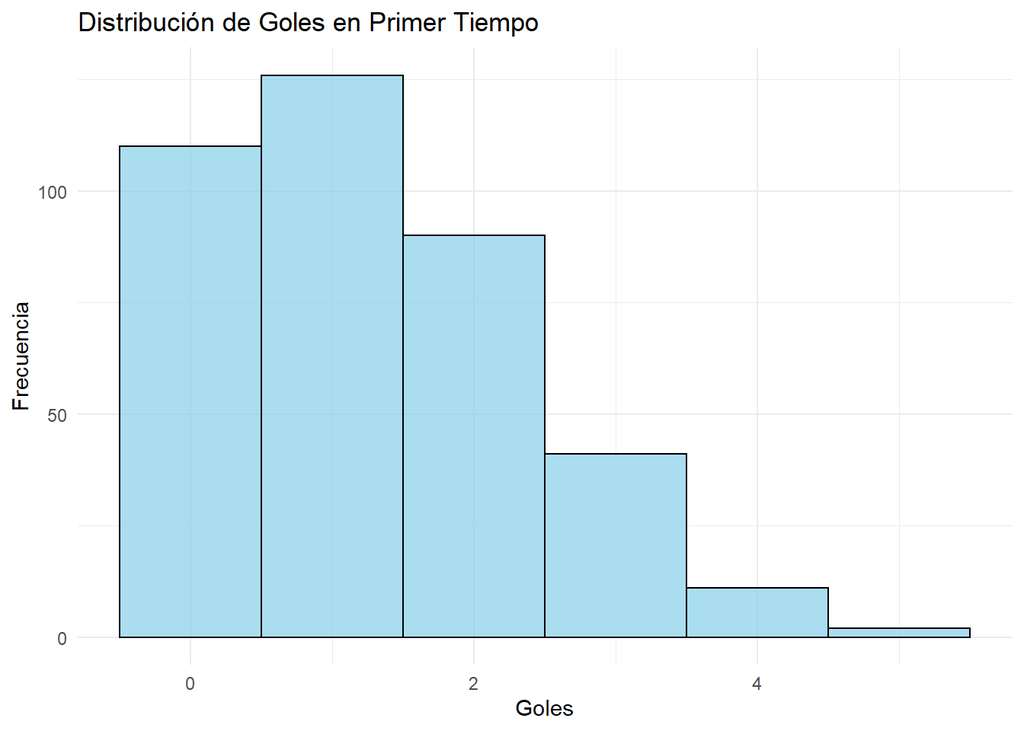

```r
# Crear un dataframe con las variables de interés
df_goles <- data.frame(
  goles_1er_tiempo = c(HTHG + HTAG),
  goles_2do_tiempo = c(goles_full_tiempo - (HTHG + HTAG))
)

# Crear el gráfico de histograma para goles en el primer tiempo
ggplot(df_goles, aes(x = goles_1er_tiempo)) +
  geom_histogram(binwidth = 1, fill = "skyblue", color = "black", alpha = 0.7) +
  labs(title = "Distribución de Goles en Primer Tiempo", x = "Goles", y = "Frecuencia") +
  theme_minimal()
```

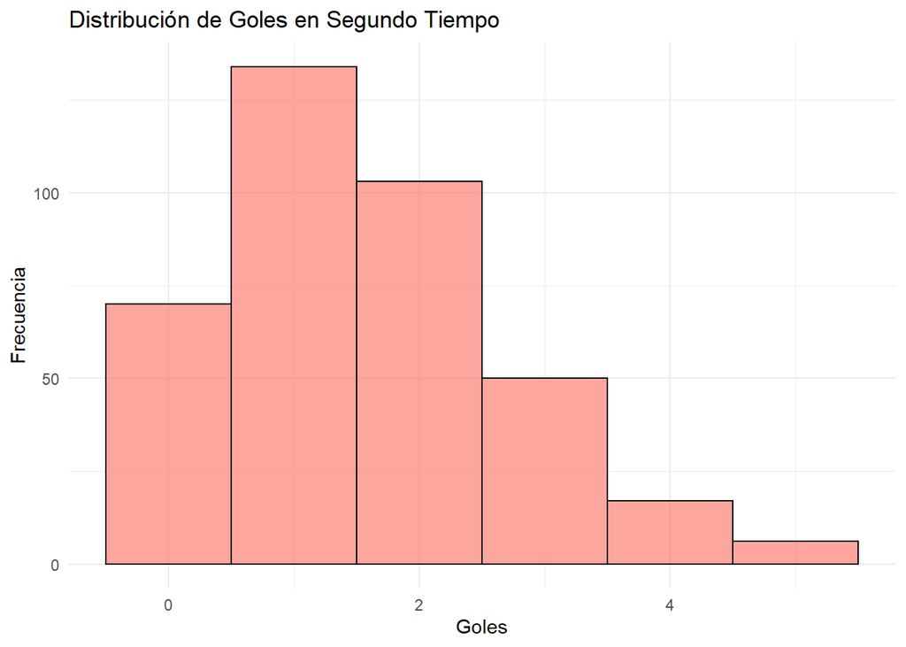

```r
# Crear el gráfico de histograma para goles en el segundo tiempo
ggplot(df_goles, aes(x = goles_2do_tiempo)) +
  geom_histogram(binwidth = 1, fill = "salmon", color = "black", alpha = 0.7) +
  labs(title = "Distribución de Goles en Segundo Tiempo", x = "Goles", y = "Frecuencia") +
  theme_minimal()
```

Se observa distribuciones similares, por lo visto, pero una frecuencia mayor infiere que en el 2do tiempo se suelen hacer más goles. Para realizar una comparacion pertinentes se realizara un test de medias.

```r
#Test de normalidad, para comprobar si utlizare test PARAMETRICOS (más potentes) o NO PARAMETRICOS
shapiro.test(df_goles$goles_1er_tiempo)
```

```
##
##  Shapiro-Wilk normality test
##
## data:  df_goles$goles_1er_tiempo
## W = 0.87714, p-value < 2.2e-16
```

```r
shapiro.test(df_goles$goles_2do_tiempo)
```

```
##
##  Shapiro-Wilk normality test
##
## data:  df_goles$goles_2do_tiempo
## W = 0.89845, p-value = 3.162e-15
```

```r
#Shapiro-Wilk normality test
#H0)Los datos se ajustan a una distribucion normal.
```

Con un PV <= alpha. Alpha=0.05. Se rechaza la hipotesis nula para ambos casos, no se pueden realizar test parametricos para comparar las medias. Por lo tanto proceso por el camino no parametrico con el Test Wilcox.test, con la funcion de muestras apeardas, porque aquí estamos comparando la misma muestra para 2 tiempos diferentes, no muestras diferentes.

```r
# Usar pivot_longer para transformar el dataframe
#necesito transformar el DF para realizar test luego, en este caso, tiempo pasa como un factor
df_goles_longer <- pivot_longer(df_goles, cols = starts_with("goles"),
                              names_to = "Tiempo", values_to = "Goles")

# Imprimir el nuevo dataframe
head(df_goles_longer)
```

```
## # A tibble: 6 x 2
##   Tiempo           Goles
##   <chr>            <dbl>
## 1 goles_1er_tiempo     1
## 2 goles_2do_tiempo     1
## 3 goles_1er_tiempo     1
## 4 goles_2do_tiempo     5
## 5 goles_1er_tiempo     1
## 6 goles_2do_tiempo     2
```

```r
#Test de wilconox (Robusto)
#es una alternativa a las pruebas de la t de Student y U de Mann-Whitney
#distribuciones no normales
#lo que plantea este test rank es comparar distribuciones, para cuantificar si existe diferencia entre las medias de las distribuciones.
wilcox.test(df_goles_longer$Goles ~ df_goles_longer$Tiempo, paired= TRUE)
```

```
##
##  Wilcoxon signed rank test with continuity correction
##
## data:  df_goles_longer$Goles by df_goles_longer$Tiempo
## V = 16832, p-value = 0.001594
## alternative hypothesis: true location shift is not equal to 0
```

Por lo tanto podemos inferir estadisticamente que, se realizan mas goles en 2do tiempo que en el 1er tiempo. Con el resultado del test inferimos que la media de goles del primer tiempo es diferente a la media de goles del 2do tiempo. Validamos la 2da hipotesis.